# Prior Choice

Carrie Holt

2022-11-4

We evaluated the sensitivity of the choice of estimation methods and model priors on (a) estimates of declines rates over 3 generations and (b) the probabilities of exceeding decline thresholds within COSEWIC Criterion A (30%, 50% and 70% declines).

Within the Metrics-COSWEIC R package, the original priors on the slope, intercept and residual sigma were applied to the unstandardized (raw) log(abundance) time-series. Specifically, these were:

- Slope: Normally distributed with a mean equal to zero and standard deviation equal to maximum log(abundance)/ length of the time-series
- Y-intercept: Normally distributed with a mean equal to the mean log(abundances) and standard deviation equal to the maximum log(abundances)
- Residual variance: Inverse gamma distributed with scale and rate parameters equal to 0.0001

### Sensitivity to estimation platform

First, for an example stock, estimates of decline rates from the Metrics-COSEWIC package using MLE, Jags, and rstanarm estimation methods were compared against those coded in stan directly using the same priors, with one exception. We applied a prior on the residual variance that was inverse gamma distributed with scale and rate parameters equal to 0.1 instead of 0.0001, which has a higher probability density at plausible sigma values, in the range of 0.1-1.5. See https://carrieholt.github.io/InvGamma.html.

The data for this example are for Fraser River Sockeye Salmon and are available from the Metric-COSEWIC package. Here we’ve chosen stock 18, an example for which decline estimates varied among estimation methods in preliminary analyses.

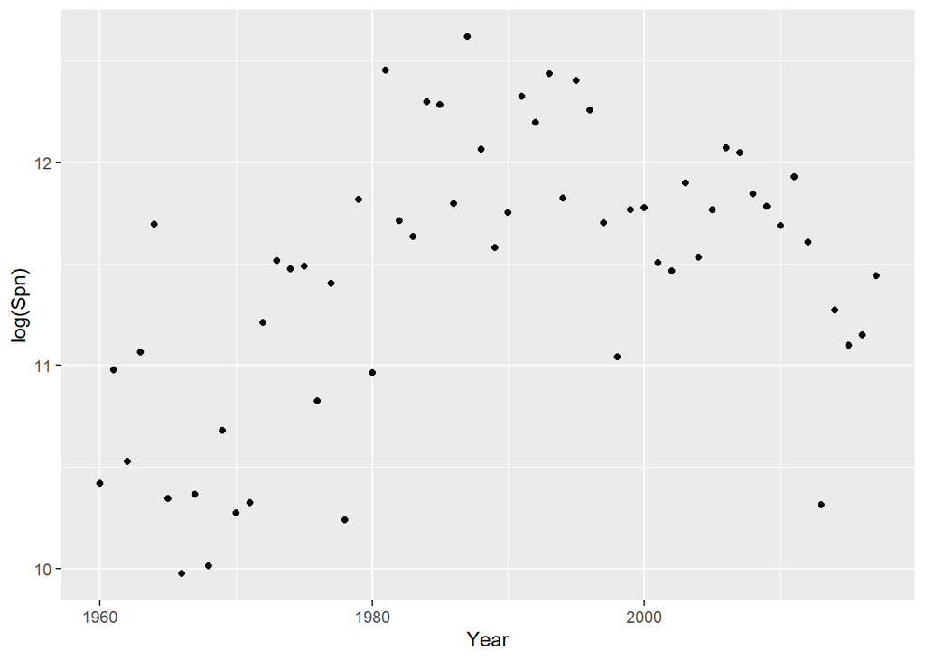

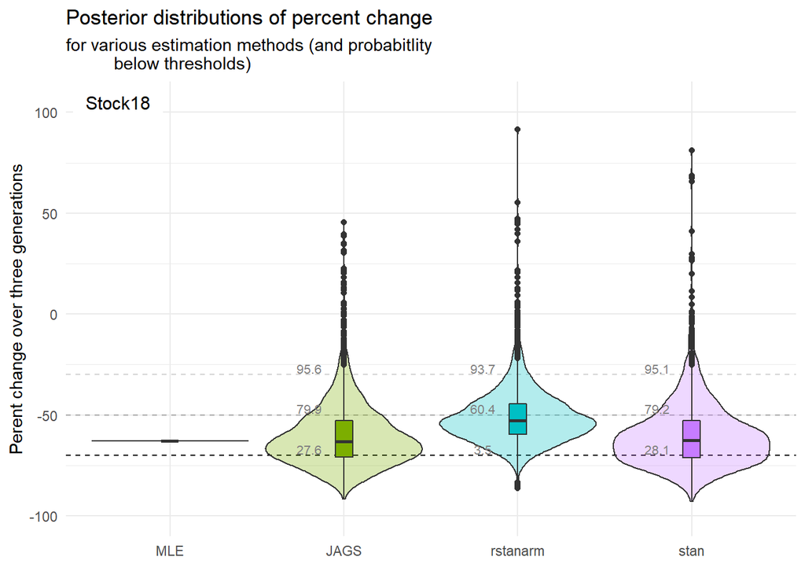

In this case, decline estimates for rstanarm (as implemented in Metrics-COSEWIC package) differ from JAGS. Rstanarm uses a default prior on the R2 value between dependent and independent variables, which differs from the assumption of normal priors used in the Jags and stan models. This implementation of rstanarm is not recommended. Results for JAGS and stan implementation were similar; stan is used for further sensitivity analyses below. Model convergence was evaluated from Rhat values and visual inspection of trace plots and posteriors distributions.

For each implementation of the stan model, the prior predictive distribution was derived, where the model was run with the priors alone ignoring the impact of data. This allows users to assess if priors cover plausible ranges of the dependent variable, as described by Wesner and Pomeranz 2021 https://esajournals.onlinelibrary.wiley.com/doi/full/10.1002/ecs2.3739. We also generated the posterior predictive distribution by simulating additional data sets from the posteriors to evaluate how this distribution compared to the observed data.

### Sensitivity to priors within stan

Next, three sets of assumptions about priors were evaluated using the stan model for estimation. as described in more detail below: (1) normal priors on slope and Y-intercept derived from unstandardized data (as specified above) versus those derived from centered and standardized data using default guidelines on normal priors from Gelman (see https://github.com/stan-dev/stan/wiki/Prior-Choice-Recommendations), (2) inverse gamma priors on residual variance compared with exponential priors on residual sigma, as recommended for rstanarm (see https://cran.r-project.org/web/packages/rstanarm/vignettes/priors.html), and (3) differences in SDs for the normally distributed priors on slope and Y-intercept, when using centered and standardized data, as described by Gelman (see https://github.com/stan-dev/stan/wiki/Prior-Choice-Recommendations).

### (1) Sensitivity to priors on standardized data

For priors applied to centered and standardized data, normal priors were applied with a mean equal to zero and sigma equal to 2.5, as suggested by Gelman (see https://github.com/stan-dev/stan/wiki/Prior-Choice-Recommendations#scaling). Decline estimates were not sensitive to centering and standardizing log(abundance) time-series in our example stock. Centering and standardizing is considered a best practice, and was used for subsequent analyses.

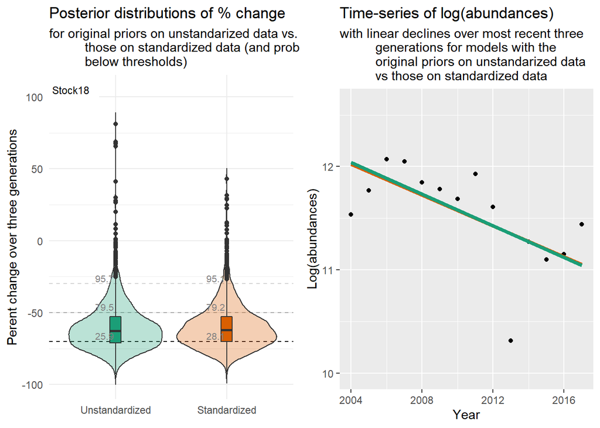

### (2) Sensitivty to distribution of priors on residuals

Sensitivity of declines estimates were evaluated to the choice of priors on residuals: inverse gamma priors on residual variance versus exponential priors on residual sigma.

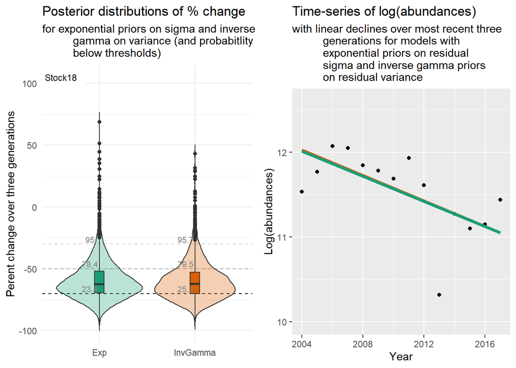

### (3) Sensitivty to SD (sigma) of normal priors on slope and Y-intercept

Sensitivity of declines estimates were further evaluated at three SDs for the normally distributed priors on slope and Y-intercept, representing generic weakly informative priors (sigma = 1), weakly informative priors (sigma =10) (both described here https://github.com/stan-dev/stan/wiki/Prior-Choice-Recommendations#5-levels-of-priors), and a moderate value between those (sigma = 2.5) as applied in rstanarm (described by Gelman, https://github.com/stan-dev/stan/wiki/Prior-Choice-Recommendations#scaling).

In this case, the slightly more informative priors (sigma=1) had a flatter slope (less severe decline) that was closer to the prior mean of zero. The weaker priors, sigma = 2.5 and sigma = 10, gave similar posterior estimates for decline rates.

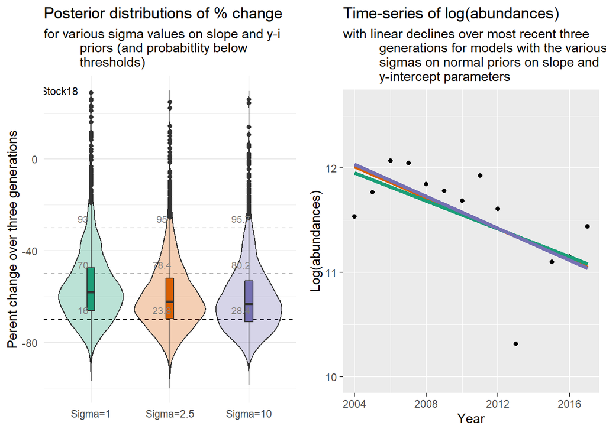